# Tracking Hospital Admission Thresholds Within Emergency Departments

Summer 2026

Authors

Affiliation

Steven Wyatt

The Strategy Unit

Andrew Jones

# Executive Summary

Most patients who are admitted to hospital in an emergency will have first passed through an Emergency Department (ED). For every ED patient, a clinician must decide whether admission is necessary, weighing a patient’s clinical needs against the availability of resources to manage those needs, either in hospital or in the community. These individual decisions - to admit or not - can be combined, at any level, to create an effective threshold for admission. An admission threshold affects the rate of emergency admissions and, in turn, influences hospital bed occupancy rates.

That relationship matters because average bed occupancy in England has hovered around 91% for the last few years. This is well above the level generally regarded as optimal for patient safety and the efficient management of patient flow. Reducing this pressure is a central aim of current NHS policy: the Ten Year Health Plan for England identifies the transfer of activity “from hospital to community” as one of its three strategic shifts, with a new neighbourhood health service intended to bring care closer to home and prevent unnecessary hospital admissions. However, because decisions to admit may be influenced by bed occupancy levels, freeing hospital capacity in this way could lead to an uncontrolled lowering of admission thresholds. In other words, hospital beds freed by moving certain activities into the community could be filled by patients who would not otherwise have been admitted. This would undermine the shift that current policy intends to deliver.

In this report, we address two questions relating to clinical admission thresholds within emergency departments. To set the scene, we set out to answer whether admission thresholds have changed in recent years. In the second part of the report, we examine whether it is feasible to routinely track these thresholds within individual emergency departments, so that local health systems can stay informed about this important factor.

**Key findings and implications**

Our first analysis, detailed in Part 1, covers attendances taking place between April 2019 and March 2025. We examined a broadly representative subset of 16 Type 1 (consultant-led 24/7) emergency departments in England. We controlled for a patient’s age, sex, ethnicity, deprivation, acuity, diagnosis, arrival mode, referral source, and time (day of the week and hour) of attendance.

An earlier study found that admission thresholds increased steadily and substantially between 2010 and 2015. This new analysis suggests that these strong secular trends appear to have ended by 2019, and have been replaced by modest fluctuations in thresholds, without a clear overall direction.

Having adjusted for clinical casemix, we find that admission thresholds fell moderately but abruptly at the start of the COVID-19 pandemic, returning to pre-pandemic levels by April 2022. During the pandemic period, patients were approximately 10% more likely to be admitted, on average, than patients with similar needs presenting at other times.

Either side of the COVID-19 pandemic and recovery period, we found that admission thresholds were more stable. Most changes that took place quarter-on-quarter may well be explained by chance alone, although our results suggest some systematic, non-seasonal patterns. Thresholds were highest in the months immediately before the pandemic and from July 2022 to June 2023. Thresholds then fell until March 2024 before rising again until December 2024. Although the odds of admission varied only modestly outside the pandemic and recovery period, the changes in this time are likely to have materially influenced admission decisions for tens of thousands of patients. Further work would be required to understand whether these modest but nonetheless material changes in admission thresholds were random, intentional, or an organic response to changes in contextual factors such as bed availability.

Ultimately, if healthcare systems are to succeed in redirecting resources from hospital to community settings, they will likely need to gain greater control over admission thresholds. Our work in Part 2 of this report suggests that it may be feasible to design statistical models and associated tools to allow health systems to track casemix-adjusted admission thresholds in individual EDs.

The models we propose are moderately complex. Moreover, since data quality varies considerably by site, each department-level model must be tuned to take account of the quality of a department’s Emergency Care Data Set submissions. Variation in the consistency of recording practices between sites also means that we should not compare the model admission thresholds across EDs.

Due to such considerations, users of these tools may require training and initial tailored support to interpret the results appropriately. Moving forward, discussions with potential users would help guide decisions about the value and nature of any tool development and deployment.

# Part 1: Changes in Thresholds for Hospital Admission Via Emergency Department

## 1.1 Introduction

In this section of the report, we explore whether and how admission thresholds within emergency departments changed between April 2019 and March 2025.

The clinical characteristics, or casemix, of patients attending emergency departments is highly heterogeneous. Some patients present with needs that almost always require admission (e.g., sepsis), whilst others (e.g., those with an ankle sprain) are very rarely admitted. Changes in the mix of patients over time, might explain why more patients are admitted in some periods than in others. In this project, the interest is in changes in admission thresholds over and above these casemix effects.

[Earlier work](https://emj.bmj.com/content/34/12/773) explored trends in casemix-adjusted admission thresholds between 2010 and 2015, and concluded that these thresholds increased substantially and steadily over this period.

Contextual factors, such as ED crowding and inpatient bed occupancy might also influence whether a patient is admitted from ED to hospital. [A 2022 study](https://emj.bmj.com/content/39/3/174) found that admission decisions were modestly associated with these contextual factors, and so should be considered as potential explanations for any observed change in casemix-adjusted admission thresholds.

The period examined in this analysis includes the COVID-19 pandemic and associated ‘lock-down’ measures. The unprecedented nature of these events led to many simultaneous changes in patient behaviours, patient needs, health service availability and clinical practice. Interpreting changes such as admission thresholds in this context is therefore challenging, and results covering the pandemic period should consequently be treated with caution and care.

## 1.2 Methods

### Data source

This analysis relied on data from the Emergency Care Data Set (ECDS). Each ECDS record represents a patient attendance at an urgent or emergency care department. We selected the subset of records coded as unplanned attendances at Type 1 emergency departments (EDs), with an arrival date between 1st April 2019 and 31st March 2025 (inclusive).

We removed records where the patient left the ED before treatment was provided; where the patient died during an attendance; and where the individual was found to be dead on arrival at the ED.

### Data quality

Whilst the ECDS is recognised as a high-quality data source, there is yet considerable variation in data quality, both across provider sites and over time. If overlooked, this variation could adversely affect the validity of our results.

We were particularly concerned, here, about the completeness and consistency of variables that indicate the clinical features and severity of a patient’s condition. These fields - *diagnosis*, *chief complaint*, and *acuity* - are likely to be the strongest predictors of admission and therefore have the greatest influence on our results. If we were to use a dataset with sizeable inconsistency in the coding of these fields (non-constant risks) over time, this could distort, and even invalidate, our results. To increase the chances that our findings would be valid, we conducted the analysis on records from a sample of sites whose data met our quality requirements.

### Selective sampling

Whilst sampling should improve the validity of our results, we can only make *general statements* about changes in admission thresholds over time if our sample of sites - and the profile of patients attending these sites - is *representative* of EDs nationwide. In other words, on aggregate, the sites and patients covered by our sample should have similar characteristics to those across England.

There is a trade-off to be made here, however. The larger our sample of sites, the more likely it is to be representative of the population of sites, and the more likely it will be that our findings are generalisable. However, the larger we make our sample, the more we compromise on data quality, which will likely decrease the validity of our results.

Details of our approach to this trade-off, and measures of representation, are given in the sections below.

We identified 138 sites that submitted data to ECDS and that had a consistent *site code* throughout the study period (2019/20 to 2024/25). These 138 EDs will represent the total population of providers that we might have used in this analysis, had data quality been universally high.

As explained above, we viewed completeness and consistency across *diagnosis*, *acuity*, and *chief complaint* fields as being particularly important to this analysis. From the population of 138 sites, we found 20 that had completeness rates for these variables that exceeded 75% in every quarter of the period studied.

Aiming for yet greater consistency, we excluded a further 3 sites (from the initial selection of 20) where completion of the *diagnosis* field decreased, on average, by more than 3% per year. And we excluded one further site that showed two sizeable step changes in completion of the *diagnosis* field. This left us with a working sample of 16 sites.

As a final step, it was necessary to verify that our intended outcome variable (whether the patient was admitted or not) was complete throughout the study period, for each site in the working sample. At the same time, we established that any change in the crude rate of admission, by site, did not exceed +/-10% from any one quarter to the next. (Such swings might have been indicative of a data quality issue.) However, each of the 16 sites in our working sample met these criteria.

#### Sites in the sample

The 16 EDs meeting the data quality criteria above are named in Table 1. Data from these sites, which covers more than 7 million attendances over 6 years, will be used in the following analysis.

Table 2 shows how the characteristics of EDs in the sample compare to the characteristics of EDs nationally. We see that the sample of EDs is slightly skewed towards smaller sites, and there is no representation of sites in London or North West England.[^1] However, the casemix of patients attending the EDs in our sample was broadly representative of the casemix of all patients who attended EDs over the period.[^2]

<sup>1</sup> When we relaxed the completeness threshold for our key variables from 75% to 70%, we saw no improvement in representation. If we were to continue to lower the threshold in search of greater representation, we may affect the validity of our results.

<sup>2</sup> It is, in fact, likely that the population casemix is *more* similar to the sample casemix than shown in Table 2. Whilst processing the data for this work, we found that sites in the population were less likely to complete the *discharge destination* field accurately, which will naturally lead to lower measured admission rates.

**Sites in sample**

Table 1: A list of sites whose data quality met our criteria for this analysis.

| id | Site Name | Trust Name |
| --- | --- | --- |
| 1 | St Mary's Hospital - Emergency Department | Isle of Wight |
| 2 | Scarborough General Hospital | York and Scarborough Teaching Hospitals |
| 3 | Airedale General Hospital | Airedale |
| 4 | The Queen Elizabeth Hospital | The Queen Elizabeth Hospital, King's Lynn |
| 5 | Treliske Hospital | Royal Cornwall Hospitals |
| 6 | Derriford Hospital | University Hospitals Plymouth |
| 7 | Great Western Hospital A&E | Great Western Hospitals |
| 8 | Salisbury District Hospital | Salisbury |
| 9 | Leeds General Infirmary | Leeds Teaching Hospitals |
| 10 | Queen Elizabeth Hospital | University Hospitals Birmingham |
| 11 | University Hospital of North Tees | North Tees and Hartlepool |
| 12 | Lincoln County Hospital | United Lincolnshire Hospitals |
| 13 | Pilgrim Hospital | United Lincolnshire Hospitals |
| 14 | Leicester Royal Infirmary | University Hospitals of Leicester |
| 15 | St Richards Hospital | University Hospitals Sussex |
| 16 | Worthing Hospital | University Hospitals Sussex |

**How representative is this sample?**

Table 2: A comparison of selected characteristics of EDs in the sample vs. all qualifying EDs in England. These statistics relate to the financial year 2024/25.

| variable | population | sample | Representation: Sample vs Pop. |
| --- | --- | --- | --- |
| n sites | 138 | 16 | 12% |
| Site-related stats (2024/25): |  |  |  |
| attendances < 65k | 25% | 50% | 203% |
| attendances 65-84k | 26% | 25% | 96% |
| attendances 85-104k | 22% | 6% | 28% |
| attendances >= 105k | 27% | 19% | 70% |
| 4h target >= 58% | 38% | 12% | 33% |
| 4h target 46%-57% | 30% | 44% | 144% |
| 4h target < 46% | 32% | 44% | 137% |
| 12h waits < 7% | 28% | 12% | 45% |
| 12h waits 7-13% | 35% | 31% | 90% |
| 12h waits >= 14% | 38% | 56% | 149% |
| also offers type 3 | 41% | 38% | 91% |
| Patient case-mix: |  |  |  |
| arrival by ambulance | 28% | 31% | 110% |
| admitted | 25% | 30% | 120% |
| age under 18 | 23% | 21% | 92% |
| age 75 plus | 18% | 20% | 110% |
| Patient demographics: |  |  |  |
| most deprived 20% | 24% | 25% | 102% |
| east of england region | 11% | 6% | 55% |
| london region | 16% | 0% | 0% |
| midlands region | 19% | 35% | 184% |
| north east and yorkshire region | 20% | 23% | 116% |
| north west region | 12% | 0% | 0% |
| south east region | 16% | 14% | 92% |
| south west region | 7% | 22% | 325% |

### Data processing

#### Addressing incompleteness

About 13% of records in the sample were missing a value in *at least one* of the fields we had planned to use in our model. Since our intended logistic regression model would not accept missing values, we had the choice to either: 1) exclude records with missing values; 2) impute missing values; or 3) assign missing values to an explicit missing category.[^3]

<sup>3</sup> This was only possible as the variables with missing values were exclusively categorical.

<sup>4</sup> If, however, the missingness was random, there is a risk that models we build could incorporate a false signal. This signal would compete with other variables for explanatory power, which may ultimately distort the coefficients of interest.

We opted for the third approach, which allowed us to make use all the records in our study dataset without the need to employ an additional (and potentially complex) imputation algorithm. This approach also allows the model to make use of the missingness signals. Importantly here, we haven’t made the assumption that data were missing at random. We believed, instead, that the missingness was more likely to be due to failures of systems and processes.[^4]

#### Creating new variables

Further to the treatment of missing values, we chose to synthesise a variable that captured the clinical features of a patient’s condition. The reasons for this were largely related to the fact that the *primary diagnosis* variable, unmodified, consisted of a large number of categories (9,800+), which would translate into a similarly large number of predictor variables. As this would likely create various problems at the modelling stage, we aimed to substantially reduce the number of predictors we would pass to the model whilst minimising the loss of information.

To produce the new variable, we used information from the *diagnosis* and *chief complaint* variables, together with the 3-tier diagnosis hierarchy from the “ECDS Refset MAX Specification”, created by NHSE.

We first created a frequency table of primary diagnoses in our sample, and recorded the 30 most frequent SNOMED codes for use in our new variable. To this list of 30, we added two SNOMED diagnosis codes related to acute COVID-19 infection.[^5] The resulting codes were equivalent to those found at Level 3 of the diagnosis hierarchy (from the ECDS Refset). Level 3 gives the most precise details of a clinical condition.

<sup>5</sup> These two codes are mapped to one condition (COVID-19).

Having removed activity with these primary diagnosis codes from our sample, we then identified the 20 most frequent chief complaint codes in the remaining data, and recorded these. These chief complaint codes were equivalent to those at Level 2 of the diagnosis hierarchy.

We mapped the remaining chief complaint codes to the ECDS Refset diagnosis table, and grouped conditions at the highest (most general) level of the diagnosis hierarchy (Level 1). Whilst there were 36 instances where the SNOMED code was labelled as “deprecated” when mapped to the Refset, we were able to categorize these manually, with the aid of archived material.

We therefore captured the clinical condition (where given) of all patients in the sample, at 3 Levels of detail, in a total of 66 categories. On examining the trends for these 66 categories, we saw evidence of codes being re-classified or dropped entirely. We attempted to reconcile these discontinuities, by:

- Uniting different codes for urinary tract infections
- Uniting different codes for injuries of the upper, and lower, extremities
- Moving “Lower limb pain” and “Upper limb pain” from Level 2 to Musculoskeletal conditions in Level 1.
- Moving “Drug and alcohol abuse” from Level 1 to “Substance misuse” in Level 2.

These changes left us with 62 categories indicating the clinical features of a patient’s condition. The proportion of attendances covered at each level of the diagnosis hierarchy is shown in Table 3, whilst the 62 categories, and plots of their appearance over time, can be seen in Figure 1, Figure 2, and Figure 3 .

**Coverage**

Table 3

| Level of grouping | Specificity of label | % sample covered |
| --- | --- | --- |
| 3 | High | 38.5% |
| 2 | Medium | 36.6% |
| 1 | Low | 24.9% |

The proportion of attendances in the sample that is covered by each level of the ECDS Refset diagnosis hierarchy.

**Condition Level 3**

Figure 1:

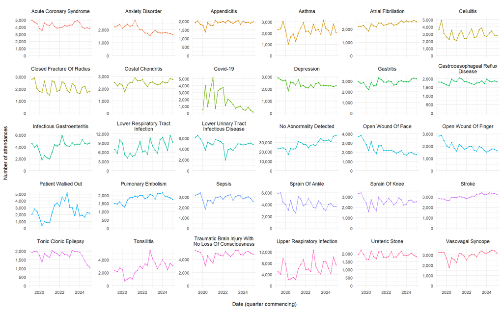

**Condition Level 2**

Figure 2:

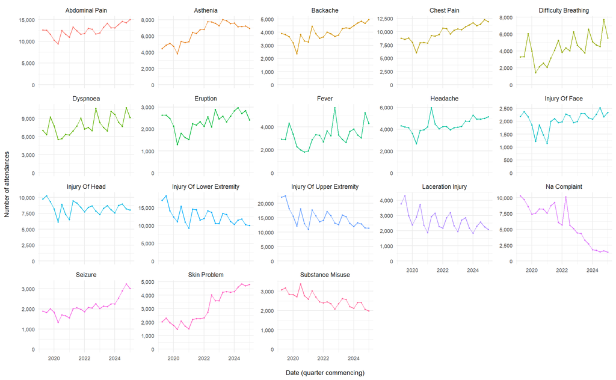

**Condition Level 1**

Figure 3:

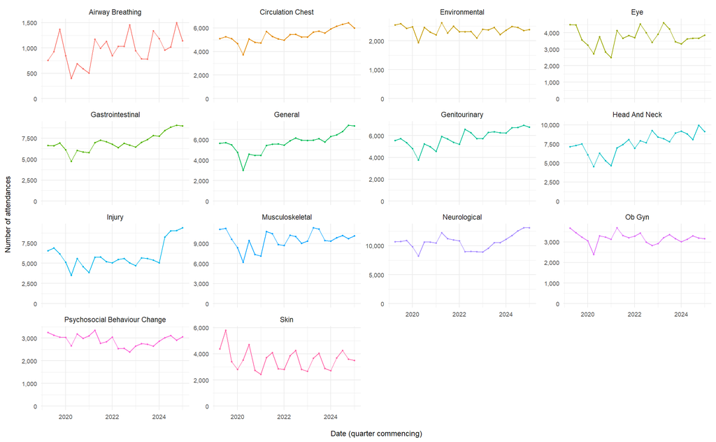

Moving on to other variables, we created new levels of the acuity variable – merging two or more of the original levels – for 3 EDs where we observed erractic recording of acuity levels over time.

We created a new *referral source* variable consisting of six levels, which blended categories from the *attendance source* field.

Finally, we created 4 new binary variables indicating whether the patient:

1. Arrived at ED by ambulance (of any type)
2. Arrived at night (which we took to be 8pm - 8am)
3. Arrived at a weekend
4. Was admitted, or not

This last variable would become the outcome variable in our model. It was derived using two fields: *discharge destination* and *discharge status*. We categorised all patients with a *discharge destination* code indicating that they were moved to a ward, operating theatre, or special/high/intensive care unit as “admitted patients”. All other patients were provisionally classified as “not admitted”. If, however, a *discharge status* code indicated that a patient was discharged to Same Day Emergency Care; to an urgent treatment centre; or to the care of a GP; the *discharge status* code would trump any value given by *discharge destination*, and the patient would be categorised as “not admitted”.

### Model specification

We fitted a logistic generalised additive model (logistic GAM) to the processed data, with our binary outcome variable being whether the patient was admitted or not. Our variable of interest was the quarter of the financial year in which a patient attended. We also included variables to adjust for casemix (as far as possible), namely: *age* (as a spline-based smooth) interacting with *sex*; *acuity*; the new, primary diagnosis variable; whether the patient arrived by ambulance or not; and the *referral source*. We incorporated variables to account for the ethnicity and socioeconomic status of patients.[^6]<sup>,</sup> [^7] In addition, we included time-related variables to control for weekday or weekend attendances, and whether the attendance was during the night (8 pm to 8 am). The ED site was the final variable in the model.

<sup>6</sup> The ethnicity variable contained 18 categories which broadly corresponded to the high-level groups used by the ONS in the 2021 census.

<sup>7</sup> The Index of Multiple Deprivation quintile covering the area in which a patient lived was used a proxy for socioeconomic status.

As graphical evidence indicated that different sites might interpret a patient’s acuity level in different ways (and the acuity variable would likely be highly influential), we included an interaction between ED site and acuity. For similar reasons, we also included an interaction between ED site and the “NA complaint” variable.

We intentionally omitted contextual factors such as the level of crowding and the inpatient occupancy at the time a patient was treated. Whilst it is true that such variables are challenging to engineer for an extended time period, we also wanted to leave these factors as possible explanations for any changes seen in admission thresholds. If we were to adjust for such effects they would not (in theory) be visible in the time series.

We fitted the model to a random sub-sample of 2.5 million records.

### Reproducibility

The computer code used in this analysis can be found a [GitHub repository](https://github.com/The-Strategy-Unit/tracking_adm_thresholds) (permissions currently required).

## 1.3 Results

The aim of this analysis was to describe national-level changes in the threshold for hospital admission via ED. We used a logistic GAM to estimate the casemix-adjusted odds of admission over time. Model coefficients corresponding to each quarter of each financial year in the study period are the values of interest. We show these values, and their 95% confidence intervals, in Figure 4. The reference level (with an odds ratio of 1) is the first quarter in the study period: Quarter 1 of 2019/20.

If we look beyond the obvious rise during the pandemic, these estimates suggest the odds of admission immediately prior to the pandemic were similar to the odds in the post-pandemic period. If we compare quarter with quarter, across the pre- and post-pandemic periods ( as in Figure 5 ), few of the differences we see are statistically significant. However, the final column in Table 4 suggests variation in admission thresholds over the period studied will have influenced the trajectory of many thousands of ED patients in our sample, and tens of thousands nationally.

**Coefficients of year-quarter**

Figure 4: Changes in the casemix-adjusted odds of admission via ED, between 2019/20 Quarter 1 and 2024/25 Quarter 4.

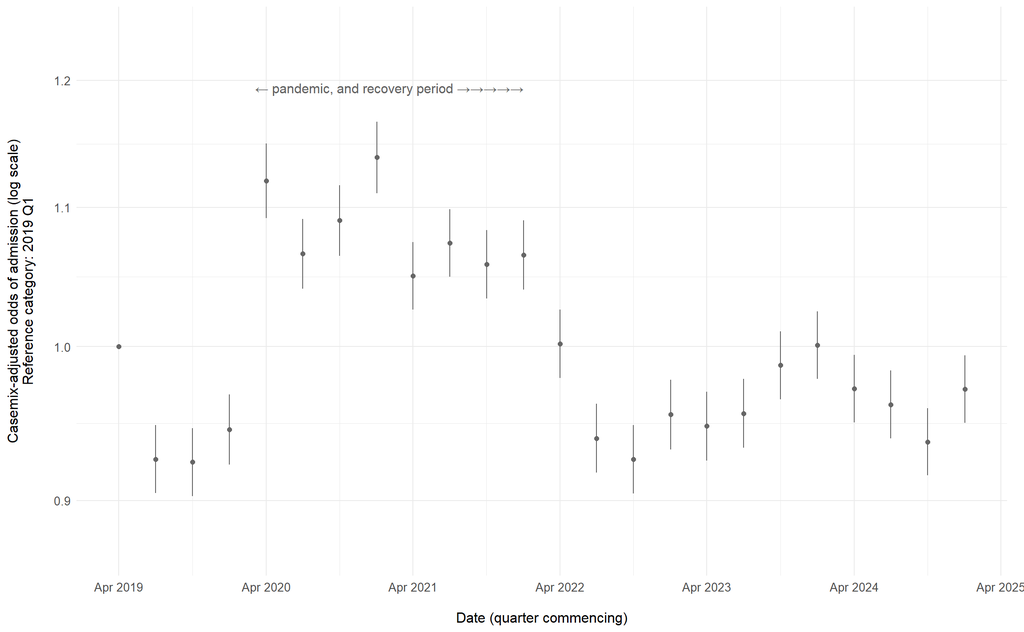

**Panels by quarter**

Figure 5: Changes in the casemix-adjusted odds of admission via ED, between 2019/20 and 2024/25. Results for each quarter are shown in separate panels to facilitate comparison.

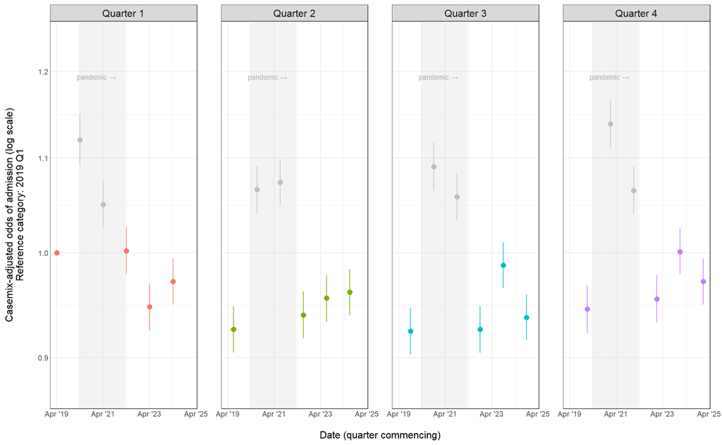

**Numbers affected**

Table 4

| Financial Year | Quarter | Attendances | Admissions Observed | Admissions Predicted | Admissions Counterfactual<sup>1</sup> | Admissions Difference (Pred. - Cf.) |
| --- | --- | --- | --- | --- | --- | --- |
| 2019/20 | Q1 | 315,906 | 90,802 | 90,975 | 90,975 | 0 |
| 2019/20 | Q2 | 320,543 | 90,269 | 89,786 | 92,954 | −3,168 |
| 2019/20 | Q3 | 313,189 | 94,135 | 94,100 | 97,383 | −3,283 |
| 2019/20 | Q4 | 273,070 | 84,861 | 84,672 | 86,738 | −2,066 |
| 2020/21 | Q1 | 212,070 | 71,951 | 72,044 | 68,776 | 3,268 |
| 2020/21 | Q2 | 281,258 | 87,441 | 87,626 | 85,264 | 2,362 |
| 2020/21 | Q3 | 253,260 | 85,998 | 86,233 | 83,204 | 3,028 |
| 2020/21 | Q4 | 238,642 | 84,050 | 84,359 | 80,034 | 4,324 |
| 2021/22 | Q1 | 315,650 | 95,677 | 95,849 | 93,837 | 2,012 |
| 2021/22 | Q2 | 315,012 | 94,928 | 95,056 | 92,117 | 2,939 |
| 2021/22 | Q3 | 301,495 | 93,189 | 92,863 | 90,592 | 2,271 |
| 2021/22 | Q4 | 287,253 | 87,180 | 87,422 | 85,042 | 2,380 |
| 2022/23 | Q1 | 307,506 | 87,661 | 88,140 | 88,064 | 76 |
| 2022/23 | Q2 | 300,007 | 85,023 | 84,811 | 87,249 | −2,439 |
| 2022/23 | Q3 | 309,123 | 87,675 | 87,851 | 90,961 | −3,110 |
| 2022/23 | Q4 | 286,600 | 84,589 | 84,419 | 86,189 | −1,770 |
| 2023/24 | Q1 | 310,721 | 89,250 | 89,494 | 91,699 | −2,205 |
| 2023/24 | Q2 | 310,877 | 91,329 | 91,115 | 92,986 | −1,870 |
| 2023/24 | Q3 | 312,243 | 93,998 | 93,851 | 94,390 | −540 |
| 2023/24 | Q4 | 306,977 | 93,535 | 93,477 | 93,436 | 42 |
| 2024/25 | Q1 | 315,318 | 95,080 | 95,221 | 96,436 | −1,215 |
| 2024/25 | Q2 | 312,756 | 95,292 | 95,494 | 97,166 | −1,672 |
| 2024/25 | Q3 | 336,110 | 98,904 | 98,539 | 101,439 | −2,901 |
| 2024/25 | Q4 | 322,348 | 94,310 | 94,478 | 95,710 | −1,232 |

<sup>1</sup> If threshold remained at level seen in 2019/20 Q1.

The number of attendances in the full sample dataset for each quarter in the study period. We also show the numbers of observed and predicted admissions, alongside the number of admissions that would have been seen had thresholds remained at the level seen in 2019/20 Q1.

## 1.4 Discussion

Having adjusted for clinical casemix, we find that admission thresholds fell moderately but abruptly at the start of the COVID-19 pandemic, returning to pre-pandemic levels by April 2022. During the pandemic period, patients were approximately 10% more likely to be admitted, on average, than patients with similar needs presenting at other times.

Outside of the COVID-19 pandemic and recovery period, we found that admission thresholds were more stable. Most changes that took place quarter-on-quarter may well be explained by chance alone, although our results suggest some systematic, non-seasonal patterns. Thresholds were highest in the months immediately before the pandemic and during the period from July 2022 to June 2023. Thresholds then reduced until March 2024 before rising again until December 2024. Although the odds of admission changed only modestly outside the pandemic and recovery period, these changes are likely to have materially influenced the admission decisions of thousands of patients each year.

Further work would be required to understand whether these modest but nonetheless material changes in admission thresholds were random, intentional, or an organic response to changes in contextual factors such as bed availability.

If healthcare systems are to succeed in redirecting resources from hospital to community settings, they will likely need to gain greater control over admission thresholds.

## 1.5 Conclusion

In the first part of this report, we have examined changes in the threshold for admission to hospital between April 2019 and March 2025. The analysis is based on a small but broadly representative subset of Type 1 emergency departments in England. We conclude that admission thresholds fell during the COVID-19 pandemic and recovery period and fluctuated modestly in the preceding and subsequent years.

## 1.6 Appendix

#### Model performance measures

The fitted model scored an AUROC of 0.866 and a Brier Score of 0.132. Performance measures were calculated on out of (sub-) sample data, which should improve the robustness of these statistics.

#### Selected additional model coefficients

**Sex**

Figure 6:

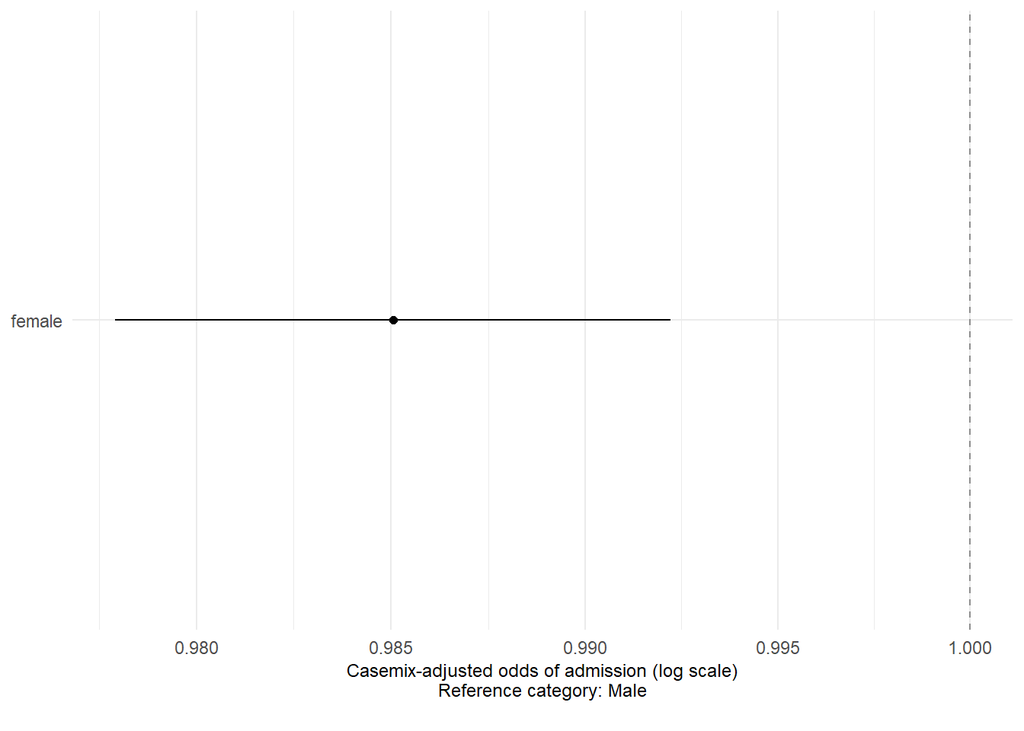

**Deprivation**

Figure 7:

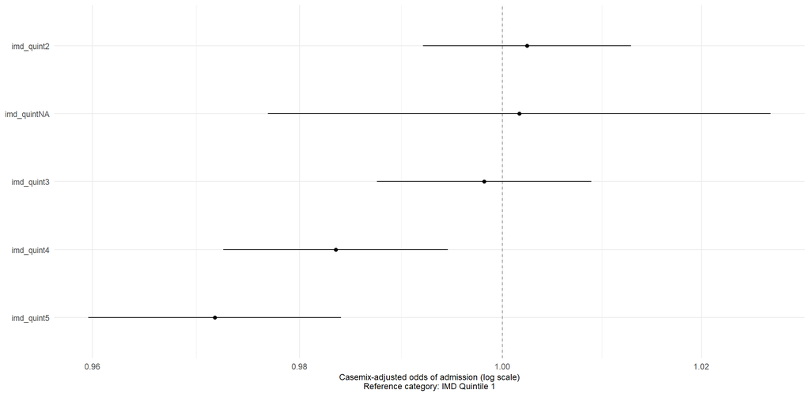

**Ethnicity**

Figure 8:

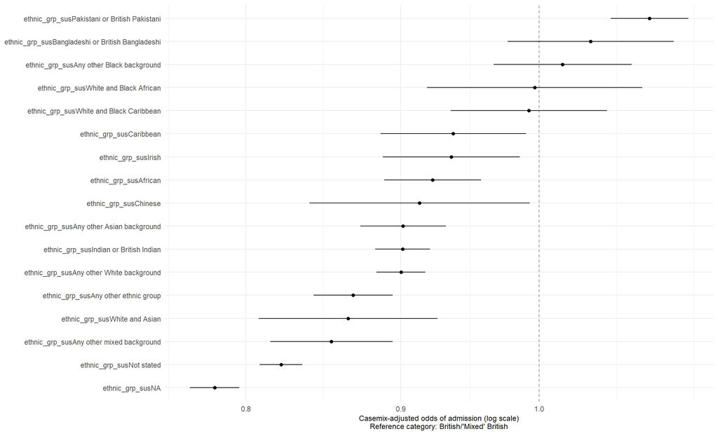

**Weekend**

Figure 9:

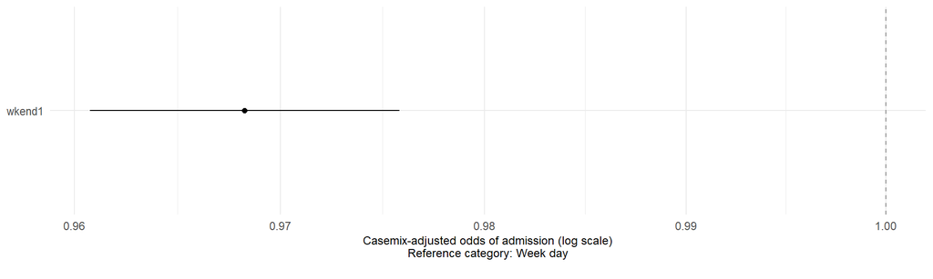

**Night time**

Figure 10:

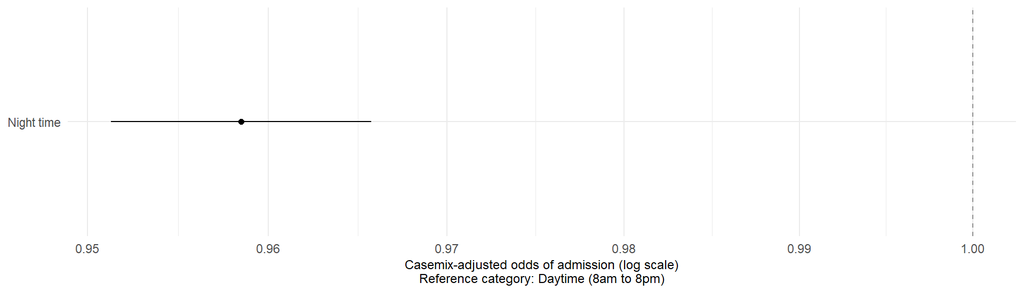

**Diagnosis**

Figure 11:

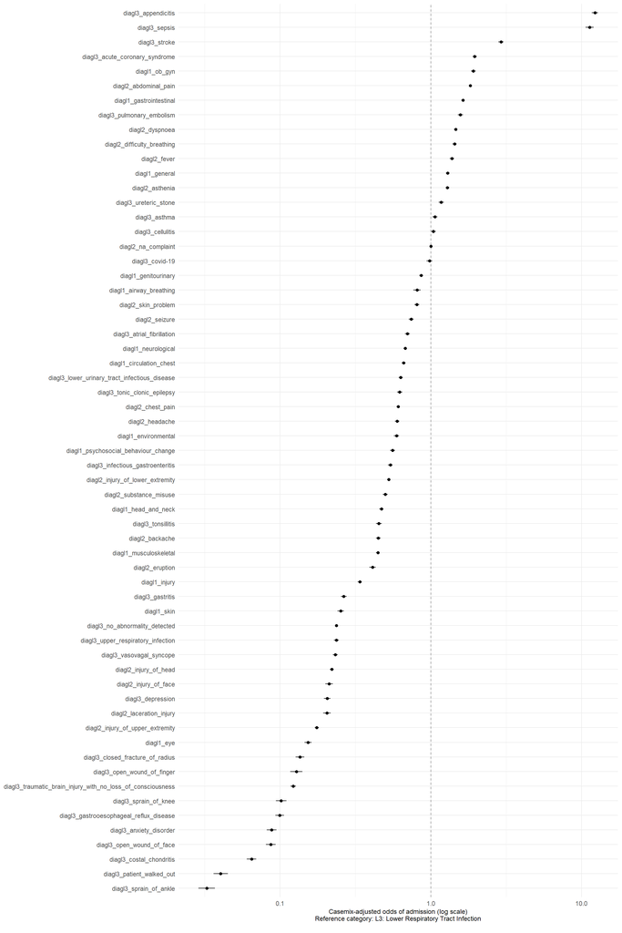

**Acuity**

Figure 12:

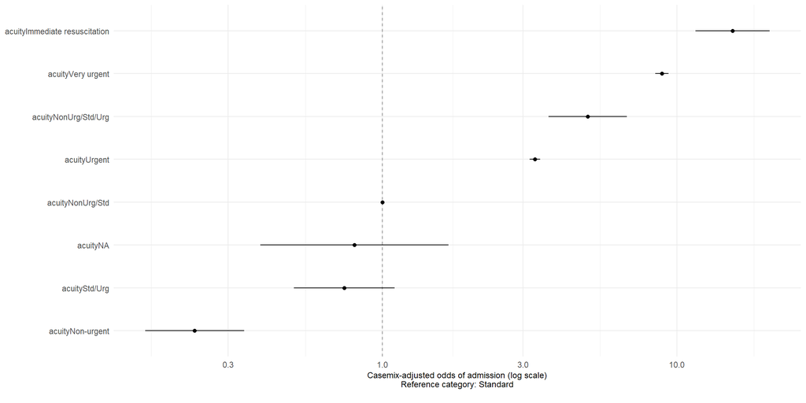

**Arrival mode**

Figure 13:

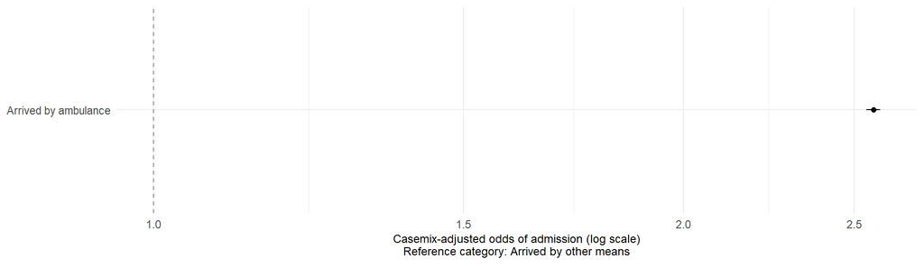

**Referral Source**

Figure 14:

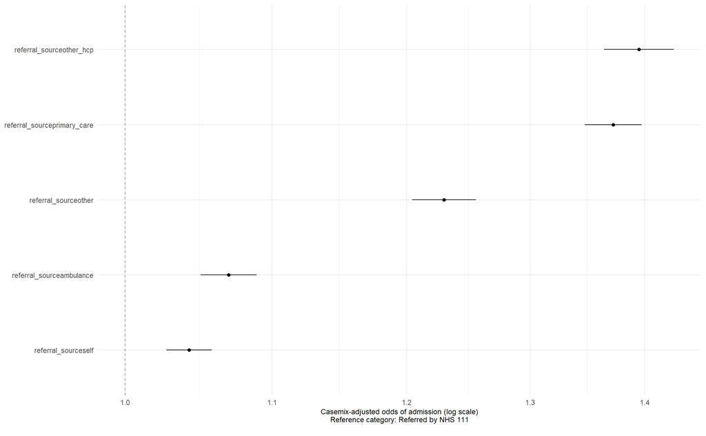

# Part 2: Tracking Thresholds for Hospital Admission via Emergency Department

## 2.1 Introduction

In the second part of this report, we propose methods, founded on statistical models, that would allow local areas to monitor whether casemix-adjusted admission thresholds are changing over time.

We have imagined that such information might ultimately be incorporated in a simple software application (app). Using this app, a user might choose any one of 180 Type 1 (24 hour, consultant-led) emergency departments (EDs) and be shown how admission thresholds at that site are changing. The app could also include graphics and text summaries to illustrate how data quality and model-design choices have influenced the trends they are shown.

## 2.2 Methods

For each Type 1 ED, we aimed to show if, and by how much, thresholds for admission are changing over time. To achieve this, we fitted regression models to emergency care data to estimate the casemix-adjusted odds of admission for each week (the higher the odds of admission, the lower the admission threshold).

### Data source

This work relied on data from the Emergency Care Data Set (ECDS). Each ECDS record represents a patient attendance at an urgent or emergency care department. We selected the subset of records that were coded as unplanned attendances at Type 1 emergency departments, with an arrival date between 1st April 2025 and 19th October 2025 (inclusive).

We excluded records where the patient left the ED before treatment was provided; where the patient died during an attendance; and where the individual was found to be dead on arrival at the ED.

Table 5 provides an example of how these choices affect the number of emergency attendances included from a given provider (in this case Hull Royal Infirmary).

Table 5: The effect of our chosen exclusions on the number of emergency care attendances included for Hull Royal Infirmary.

[output not shown]

### Data quality considerations

Whilst the ECDS is recognised as a high-quality data source, there is yet considerable variation in data quality, both across provider sites and over time. We examine the issues we observed, and detail our solutions, below.

#### Data quality over time

We chose to use records in which the patient arrived at a ED on or after April 1st 2025, in the belief that this would 1) minimise the variation in data quality that occurs over an extended period; and 2) provide sufficient context in which to interpret current measurements of admission thresholds.

There was a further balance to achieve when thinking about an end date to our period of study. With an app in mind, we wanted our estimates of admission thresholds to run close to the current date, since the objective would be to present relevant and actionable information. However, data quality can be low for very recent data, due to the way data is incrementally flowed from providers to the ECDS. We therefore programmed a rolling end date to our study, and a buffer period, such that the most recent data point would cover the last complete week (Mon-Sun) occurring at least 21 days before the computer code was executed.[^8] This buffer period should increase the chances that all sites had submitted high quality data across every field.

<sup>8</sup> In the case of the text and graphics presented in Part 2 (excepting Figs. 18-21), the computer code was executed on November 10th 2025, which makes the last complete week the 13-19th October 2025.

#### Data quality by site

When examining data quality by site, we observed issues that could be characterised as being: a) accuracy-related; and b) completeness-related. Here, we examine these dimensions separately:

##### Addressing inaccuracy

We are detached from the data-generating and data-capture processes, and therefore we can only infer that data did not represent real-world events. For example, at several sites we observed that almost all patients were coded as having been sent home, as shown in Table 6.

This data is unlikely to reflect the reality at major EDs. In this case, therefore, we chose to exclude 5 sites with crude admission rates below 5%.

Table 6: Emergency departments with the lowest crude admission rates. We excluded sites with rates below 5%, as these are unrealistically low.

| Site of emergency department | % Attendances resulting in admission |
| --- | --- |
| Royal Surrey County Hospital | 0.10% |
| Weston General Hospital | 0.55% |
| The Princess Alexandra Hospital | 1.90% |
| Croydon University Hospital | 4.85% |
| Cheltenham General Hospital | 4.96% |
| Bassetlaw District General Hospital | 5.18% |
| Horton General Hospital | 5.30% |
| Musgrove Park Hospital | 7.53% |
| Macclesfield District General Hospital | 7.54% |
| St Peter's Hospital | 8.10% |
| University College Hospital | 8.99% |

##### Addressing incompleteness

At a site level, on average, 72% of records were missing a value in *at least one* of the fields we had selected for our models. Since our intended regression models would not accept missing values, we had the choice to either: 1) exclude records with missing values; 2) impute missing values; or 3) assign missing values to an explicit missing category.[^9]

<sup>9</sup> This was only possible as the variables with missing values were exclusively categorical.

We opted for the third approach, which allowed us to make use all the records in our study dataset without the need to employ additional (and potentially complex) imputation algorithms. This approach especially useful when fitting models for smaller sites, where the number of records (n) we have for that site may not greatly exceed the number of predictor variables (p) that we wish to include in our regression models. As p –> n, we get closer to an over-fitted, under-powered model, which will be more likely to produce inaccurate predictions and be incapable of distinguishing between genuine effect and random variation.

The approach we used also allows the model to make use of the missingness signals. Importantly here, we haven’t made the assumption that data were missing at random. We believed, instead, that the missingness was more likely to be due to failures of systems and processes. If, however, the missingness was random, there is a risk that models we build could incorporate a false signal. This signal would compete with other variables for explanatory power, which may ultimately distort the coefficients of interest.

#### Addressing non-constant risks

There are other potential hazards that could be amplified by the approach we took to address missing variables. The first is that of non-constant risks by week. By this, we mean that coding practices at a site - which might include the information that goes *uncoded* - could vary greatly from week to week. And if, for example, admission rates of patients with a missing diagnosis varied greatly from week to week - because of large changes in the casemix that goes uncoded - this would distort our coefficients of interest.

In order to highlight results that may have been affected by non-constant risks by week, we produced a second set of models. The details of these models, and how such models were used to identify possible non-constant risks by week, can be found in the Model Specification section, below.

In addition to non-constant risks over time, we must also consider non-constant risks across sites. A [2017 Strategy Unit study](https://www.strategyunitwm.nhs.uk/publications/changes-admission-thresholds) found evidence of inconsistent coding across EDs for key casemix variables. Intermediate results from the current analysis would suggest that these issues remain in the most recent ECDS data. We have therefore deemed it inappropriate to compare admission thresholds between EDs.

### Additional data processing

Further to the treatment of missing values, we created a new *referral source* variable consisting of six levels, which combined categories from the *attendance source* field. We created 3 new binary variables indicating 1) whether the patient arrived at ED by ambulance (of any type); 2) whether the patient arrived outside daytime hours (or 8pm - 8am); and 3) whether the patient arrived at a weekend.

Importantly, we chose to re-engineer the *primary diagnosis* and *chief complaint* variables. Both of these variables, unmodified, consisted of a large number of categories (9,800+ for diagnosis and 200+ for complaint). As implied above, if we can substantially reduce the number of predictors whilst minimising the loss of information, we are likely to improve our models. Therefore, for both *primary diagnosis* and *chief complaint*, we grouped together less frequent conditions with the aid of a [3-tier hierarchy (the “ECDS Refset”, created by NHSE)](https://digital.nhs.uk/data-and-information/data-collections-and-data-sets/data-sets/emergency-care-data-set-ecds/ecds-guidance). We conducted this grouping at the site level. As a consequence, groupings may vary, slightly, from site to site.

##### Diagnosis grouping

Across sites, the top 30 diagnoses accounted for an average of 60% of records.[^10] When re-engineering diagnosis, we there left the 30 most frequent diagnosis codes un-grouped (thus retaining the most precise diagnosis information). We then grouped the remaining diagnoses at a higher (medium-precision) level, and chose the 10 most frequent of these medium-precision diagnosis labels. Finally, we grouped the remaining diagnoses at the highest, most general level of the hierarchy.

<sup>10</sup> Missing diagnoses are included in this 60%.

This resulted in a median of 51 distinct diagnosis levels per site (lower quartile = 46, upper quartile = 52). An example for the ED at the Royal Liverpool University Hospital is shown in Table 7.

Table 7: Categories in the re-engineered diagnosis variable. This data is specific to the Royal Liverpool University Hospital.

| Grouping level<sup>1</sup> | Diagnosis | Number of attendances | % of attendances |
| --- | --- | --- | --- |
| 3 | No abnormality detected | 10,376 | 22.9% |
| 1 | Medical specialties | 3,443 | 7.6% |
| 2 | Closed fracture | 1,468 | 3.2% |
| 1 | Infectious disease | 1,452 | 3.2% |
| 1 | Cardiovascular | 1,265 | 2.8% |
| 2 | Wound lac incised bite | 1,191 | 2.6% |
| 2 | Sprain ligament injury | 1,120 | 2.5% |
| 1 | Urinary tract | 976 | 2.2% |
| 1 | Trauma fb | 970 | 2.1% |
| 3 | Na | 955 | 2.1% |
| 1 | Other engineered | 923 | 2.0% |
| 3 | Depression | 855 | 1.9% |
| 1 | Musculoskeletal | 849 | 1.9% |
| 1 | Head and neck | 807 | 1.8% |
| 2 | Gi lower function | 765 | 1.7% |
| 2 | Muscle injury | 761 | 1.7% |
| 3 | Gastritis | 749 | 1.7% |
| 3 | Lower respiratory tract infection | 735 | 1.6% |
| 3 | Sepsis | 724 | 1.6% |
| - | Other | 14,851 | 32.8% |

<sup>1</sup> Level of 3-tier hierarchy (from the 'ECDS refset') at which the diagnosis code was grouped. Level 3 gives the most precise information available.

##### Complaint grouping

We followed a similar process with the chief complaint field.[^11] We left the most frequent 50 chief complaints un-grouped (these accounted for an average of 84% of records per site).[^12] We then grouped the remaining chief complaints at the highest, most general level.

<sup>11</sup> Note that, unmodified, the detail given in the chief complaint field is equivalent to the second level of the 3-tier hierarchy, so we only have two levels in this case.

<sup>12</sup> Missing complaints are included here.

This grouping resulted in a median of 65 distinct complaint levels (lower quartile = 65, upper quartile = 66). An example for the ED at Frimley Park Hospital is shown in Table 8.

Table 8: Categories in the re-engineered complaint variable. This data is specific to Frimley Park Hospital.

| Grouping level<sup>1</sup> | Complaint | Number of attendances | % of attendances |
| --- | --- | --- | --- |
| 2 | Na | 10,134 | 13.9% |
| 2 | Abdominal pain | 6,458 | 8.9% |
| 2 | Chest pain | 4,967 | 6.8% |
| 2 | Injury of head | 2,674 | 3.7% |
| 2 | Skin problem | 2,408 | 3.3% |
| 2 | Fever | 2,333 | 3.2% |
| 2 | Asthenia | 2,230 | 3.1% |
| 2 | Falls | 2,104 | 2.9% |
| 2 | Dyspnoea | 2,006 | 2.8% |
| 2 | Difficulty breathing | 2,002 | 2.8% |
| 2 | Vomiting | 1,853 | 2.5% |
| 2 | Headache | 1,767 | 2.4% |
| 2 | Backache | 1,725 | 2.4% |
| 2 | Dizziness | 1,486 | 2.0% |
| 1 | Injury | 1,450 | 2.0% |
| 1 | Musculoskeletal | 1,149 | 1.6% |
| 2 | Palpitations | 1,041 | 1.4% |
| 2 | Laceration injury | 1,008 | 1.4% |
| 2 | Injury of face | 966 | 1.3% |
| - | Other | 22,926 | 31.5% |

<sup>1</sup> Level of hierarchy (from the 'ECDS refset') at which the chief complaint code was grouped. Level 2 gives the most precise information available for the chief complaint.

### Variable selection: diagnosis or complaint?

In terms of variable selection, our major decision concerned two variables that each indicate a clinician’s assessment of the patient’s condition. These are:

- The *primary diagnosis* variable (hereafter referred to as *diagnosis*) indicates the main condition treated or investigated during the patient’s stay in the ED.
- The *chief complaint* variable (hereafter referred to as *complaint*), on the other hand, refers to “[the primary problem a patient is presenting with, as initially assessed by a clinician](https://www.england.nhs.uk/guidance-for-emergency-departments-initial-assessment/).”

These variables are particularly important because a clinician’s assessment of the patient’s condition is likely to be the strongest predictor of admission. We must choose just one, however, in a given model. This is due to the likely relationship (multicollinearity) between these two variables.

All else being equal, *diagnosis* provides more accurate and precise information about a patient’s condition, and would thus better allow us to control for casemix. However, if a site has coded *diagnosis* poorly compared to *complaint*, we questioned if there would be a point at which it would be beneficial to use *complaint* instead of *diagnosis*.

After testing models that used either *diagnosis* or *complaint,* and assessing these against the AUROC and Brier Score statistics, we opted to use diagnosis for each site-based model, unless: 1) diagnosis completion rate at a site was below 40% in any one week, **and** 2) the minimum complaint completion rate in any one week was 40% higher than the minimum diagnosis completion rate in any week.

There were 13 sites that met these criteria. In these cases, we used chief complaint in the model, in place of diagnosis. We therefore had two different model specifications for our principle question, and two corresponding specifications for our models to assess non-constant risks.

### Model specification

#### Primary models

We fitted a separate logistic generalised additive model (logistic GAM) for each site.

Our outcome variable was whether the patient was admitted, or not. Our variable of interest was the week that a patient attended.

As noted above, we worked with two specifications, identical other than in their use of either the re-engineered *diagnosis* or *complaint* variable.

Otherwise, we included variables to adjust for casemix (as far as possible), namely: *age* (as a spline-based smooth) interacting with *sex*; *acuity*; whether the patient arrived by ambulance or not; and the *referral source*. We incorporated variables to account for the ethnicity and socioeconomic status of patients.[^13]<sup>,</sup> [^14] In addition, we included time-related variables to control for weekday or weekend attendances, and whether the attendance was during the night (8 pm to 8 am).

<sup>13</sup> The ethnicity variable contained 18 categories which broadly corresponded to the [high-level groups used by the ONS in the 2021 census](https://www.ethnicity-facts-figures.service.gov.uk/style-guide/ethnic-groups/).

<sup>14</sup> The Index of Multiple Deprivation quintile covering the area in which a patient lived was used a proxy for socioeconomic status.

We intentionally omitted contextual factors such as the level of crowding and the inpatient occupancy at the time a patient was treated. Instead, we wanted to leave these factors as possible explanations for any changes seen in admission thresholds. If we were to adjust for such effects they would not (in theory) be visible in the time series.

#### Secondary models (to identify non-constant risks)

We produced a second set of models with which we aimed to highlight results from the primary models that may have been affected by non-constant risks.

Before fitting this second set of models, we created an additional binary variable which indicated whether the most influential predictor, *diagnosis* (or *complaint*, where applicable), was missing or not. This additional term and interaction terms created between this new variable and the *week* variable were the only differences between the primary and secondary model specifications.

We reasoned that the coefficients of the interaction terms should indicate non-constant risks, if they are present.[^15] To help illustrate our reasoning, we will use Figure 15, which shows interaction coefficients (and their 80% confidence intervals), ordered by week, for the ED at St. George’s Hospital (Tooting). On this plot we have also drawn two horizontal lines, at twice and half the median value of these interaction coefficients.[^16] These two lines represent our upper and lower bounds: if an interaction estimate and its confidence interval is fully outside these bounds, then we judged that the term – and, at root, the proportion of missing diagnoses/complaints in that week – is contributing abnormal explanatory power to the model. In this case we would flag that week’s result in our primary charts as being potentially problematic.

<sup>15</sup> If we were to look at acuity, for example, we may also observe non-constant risks, by week. However, as diagnosis and complaint are likely to be the most influential variables when estimating odds of admission, and the recording of diagnosis and complaint appears to less consistent than for other variables, we have focussed our attention here.

<sup>16</sup> The median value was used as a reference level, in preference to specific odds values, as this removed the risk of the reference category being abnormal.

Figure 15: Coefficient values for the interaction between the binary ‘missing complaint’ variable and the week variable (with 80% confidence intervals). Shown for St. George’s Hospital (Tooting). If an interaction estimate and its confidence interval appears fully outside the area bounded by parallel dotted lines, then we took this as evidence of a non-constant risk for that week.

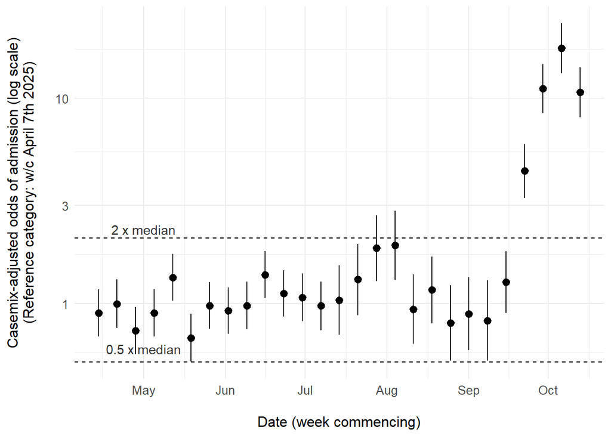

### Presentation of results

We are seeking to illustrate variation in ED-level admission thresholds over time. As noted, various factors and processes will influence whether a patient is admitted to hospital from the ED, over and above their condition.[^17] Even in a period of stability, processes will vary, randomly, from week to week. The question is, then, how can we tell when the observed variation is not random, but the result of a significant and sustained process change?

<sup>17</sup> Moreover, some factors and processes will influence whether a patient is *recorded* as being admitted to hospital. As we are inadvertantly measuring these processes too, we should be careful when attributing process changes.

#### The XmR chart

The XmR chart is a type of Statistical Process Control (SPC) chart. We can use XmR charts - together with some common SPC rules- to identify when unusual factors have influenced a system or when fundamental changes to one or more of the system’s processes have taken place.

In Figure 16, we use an XmR chart to display how the odds of admission via ED (at St. George’s Hospital, Tooting) have varied over time. The XmR chart has two components, the “X” plot and the “mR” plot:

- The “X” plot (at the top of the chart) displays how the outcome of interest changes over time. Three horizontal lines represent the mean value and the upper and lower “control limits” (at 3 sigma from the mean value).[^18] These control limits define the expected range of variation for the process in question. If a point falls between the upper and lower control limits, then the result is considered within the bounds of natural - or “common cause” - variation, and the process is deemed stable. If, on the other hand, a point is outside the control limits, this indicates that the difference from the process mean should not be attributed to random variation. In SPC terms, there is a “special cause” for the variation.
- The “mR” (moving range) plot, is displayed below the X plot, on an identical horizontal axis. This chart emphasises the process variation. Horizontal lines on the plot show the mean value and the upper control limit of the variation (at 3 sigma from the mean).[^19] A large change - positive or negative - between consecutive points in the X plot may result in an mR point that is above the upper control limit. In this case, the change in the outcome of interest (between consecutive points) is greater than might be expected for this process.

<sup>18</sup> To obtain control limits with the standard calculations, values should be normally distributed. We therefore performed these calculations on the the raw model output values (log odds ratios), which are approximately normal, and only then transformed them to the linear scale.

<sup>19</sup> Note that differences are absolute, so there is no lower control limit.

Looking at Figure 16, it appears (from the X plot) that the casemix-adjusted odds of admission at St. George’s were relatively consistent from April until the last week in September. At this point, the odds of admission rose sharply (indicating a fall in the threshold for admission). From late September, there are three consecutive points above the upper control limit. What should we read into this rise? Does this signify a clinical process change, or is it an artefact of data quality?

Figure 16: An XmR chart for St. George’s Hospital (Tooting), showing the casemix-adjusted odds of admission between April and September 2025 (top plot), and the ‘moving range’ of these odds over the same period (bottom chart).

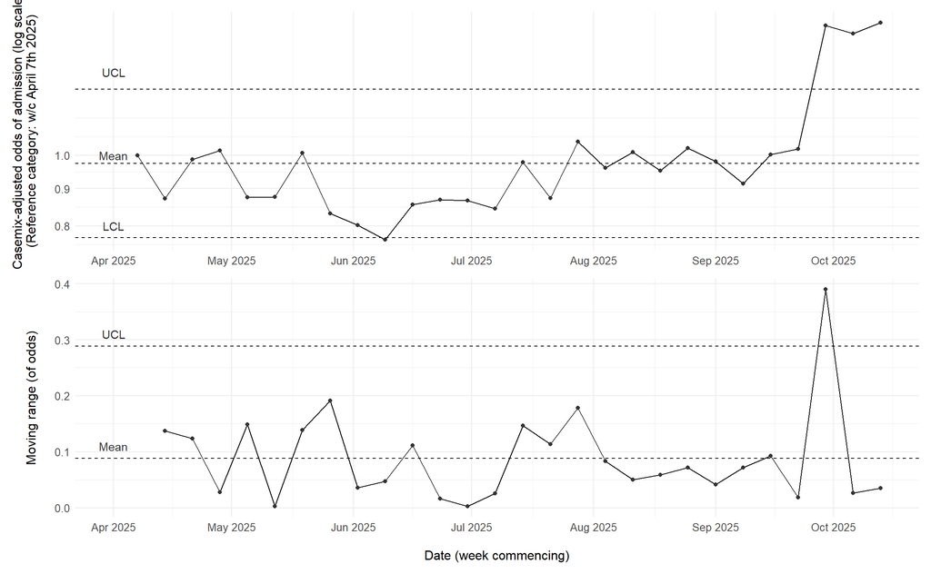

#### Highlighting data quality concerns

Special-cause variation signifies that unusual factors or processes are influencing the outcome at the time of measurement. In Figure 16, above, the special-cause variation at the end of the time series seems to be the result of an abrupt change, rather than an initiative that has produced change over an extended period.

Given the context here (an abrupt change at the end of the series), one of the most likely causes is a data quality issue. If we move on to examine Figure 17 - in which we have highlighted points affected by non-constant risk (in red) - we find that non-constant risks are indeed present in the last few weeks of the period.[^20] Due to this fact, we should question the validity of the final four data points. If we were to re-run the analysis at a later date (as one might, were these methods incorporated into a tool), it is possible that refreshed data would give us a more robust picture of the admission threshold in late September and early October.

<sup>20</sup> The points are highlighted on the basis of results from the secondary models, which will have suggested that the coding of diagnosis (or complaint) in the last few points of the time series was inconsistent with coding in the rest of the series.

Figure 17: An XmR chart for St. George’s Hospital (Tooting), showing the casemix-adjusted odds of admission between April and September 2025 (top plot), and the ‘moving range’ of these odds over the same period (bottom chart). Weeks in which non-constant risks have been identified are represented by red points.

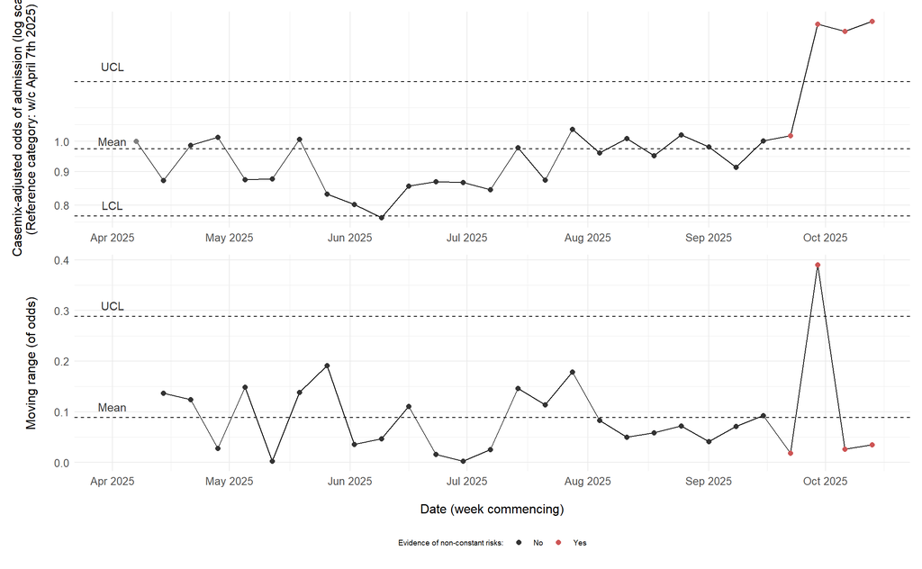

#### Detecting significant and sustained changes

If we were monitoring the admission threshold at a given ED on a regular basis, we would likely be seeking evidence of meaningful changes to the processes which influence this threshold. What, then, is the relationship between the variation we see in the threhold and process change?

The [Making Data Count (NHSE, 2019)](https://www.england.nhs.uk/wp-content/uploads/2019/12/making-data-count-getting-started-2019.pdf) publication outlines four SPC rules that can be applied to the X chart to identify a process change. These are the observation of either:

- A single point further than 3 sigma from the process mean (i.e. outside the control limits)
- Any two of three consecutive points further than 2 sigma from the process mean
- Seven consecutive points all above / all below the process mean
- [Seven] points with consecutively increasing / decreasing values [^21]

<sup>21</sup> *Making Data Count* specifies “six consecutive points.” However, we have used the `NHSRplotthedots` package to label process changes, which uses a rule of seven consecutive increasing or decreasing points. In any case, limit changes based on consecutive increasing/decreasing points are far less common than those triggered by the “seven consecutive points all above / all below the process mean” rule.

<sup>22</sup> And, as such, are likely to be factors rather than processes

The first two of these rules will be more likely to signal rapid changes or “shocks” to the system.[^22] Shocks could be due to, for example, events like industrial action, holidays, or temporary data quality issues (as we have seen above).

The latter two rules rely on trends of several points. In our case, seven points represents a trend lasting seven weeks. These last rules are therefore more likely to indicate a sustained process change.

With any process change comes a probable change in the normal performance limits of the system. Therefore, once a process change has been detected (and, ideally, verified and understood), the process mean and the control limits on the XmR chart should be recalculated. For our purposes, we have chosen to recalculate these elements only when significant and *sustained* process changes are detected.[^23] This is because our focus here is not on flagging system shocks but on monitoring sustained changes that could provide feedback to the National Neighbourhood Health Implementation Programme.

<sup>23</sup> In an app, limits would likely be updated automatically when a process shift is detected. The fact that seven points would be required for any update reduces the risk that limits are reset due to data quality issues or shocks, which are of less interest to us here.

<sup>24</sup> Smith T, Reading C, Wellesley-Miller S, Turner Z, Jemmett T, Mainey C, MacKintosh J, Fabietti M, Barton F (2025). *NHSRplotthedots: Draw XmR Charts for NHS ‘Making Data Count’ Programme*. R package version 0.2.2, https://nhsrplotthedots.nhsrcommunity.com.

In the figures below, we have illustrated how the process mean and control limits of an X chart might evolve over an extended time period. Using data from the ED at Salford Royal, we display a time series (of the odds of admission) at 12 weeks, 26 weeks, 28 weeks, and 40 weeks from the start of measurement. We implemented our chosen rules with the aid of the `NHSRplotthedots` R package.[^24]

Figure 18 shows the situation 12 weeks after measurement of the admission threshold begins. To establish a robust mean and process limits, the `NHSRplotthedots` package requires at least 12 points in the series.[^25] The process limits and mean will continue to be refined until there are 20 points in the series.

<sup>25</sup> There is no consensus on the number of points in the needed to establish reliable limits. Sources suggest between 5 and 30 points. A number closer to the upper value of this range will produce more robust limits. The `NHSRplotthedots` package constructs limits based on 12+ points. If there are fewer than 12 points in a series, “trial limits” will be drawn. See https://nhsrplotthedots.nhsrcommunity.com/articles/number-of-points-required.html for further details.

In Figure 19, we see that the results from weeks 23 to 26 are above the upper control limit. Special cause variation is therefore present, but, based on the rules we are using, there is no recalculation of the process mean and limits at this time. However, we do see a trend of 5 consecutive points above the process mean. If the points in the next two weeks continue this trend then the mean and limits will be reset.

In Figure 20, we see that this is indeed what happens. A trend of seven points above the original process mean indicates a significant and sustained change in the process. A new (trial) mean and (trial) limits are calculated, based on the variation in the seven point trend. Readings from subsequent weeks will contribute to these limits and they will become more robust as time passes. At week 40, shown in Figure 21, we see the mean and limits have been slightly revised, but points remain within the new limits.

**Week 12**

Figure 18: An X chart for Salford Royal, showing the casemix-adjusted odds of admission over the 12 weeks following April 7th 2025.

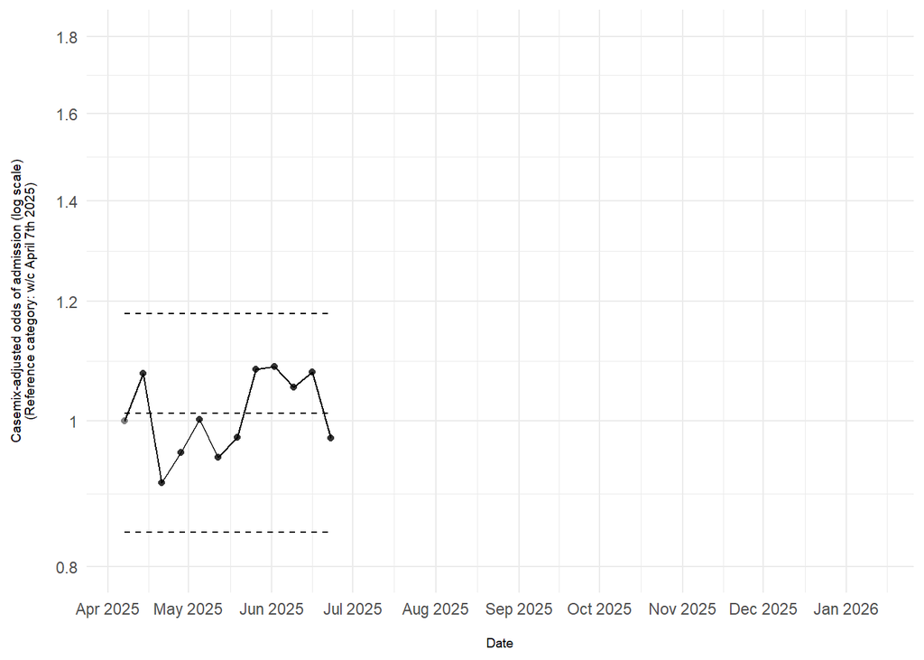

**Week 26**

Figure 19: An X chart for Salford Royal, showing the casemix-adjusted odds of admission over the 26 weeks following April 7th 2025.

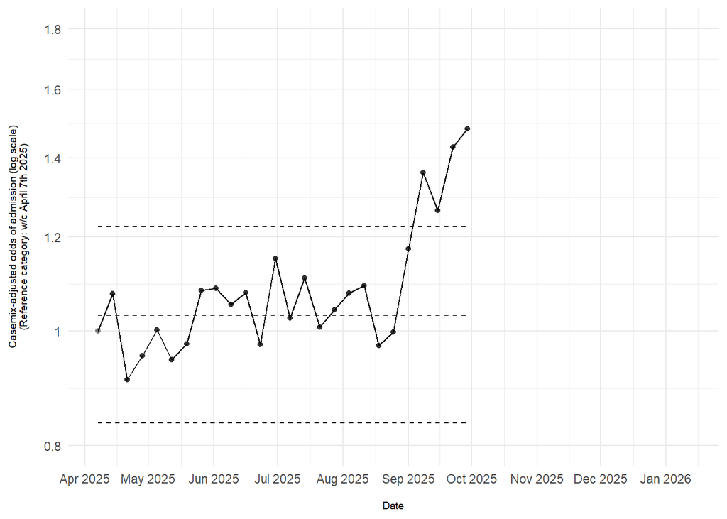

**Week 28**

Figure 20: An X chart for Salford Royal, showing the casemix-adjusted odds of admission over the 28 weeks following April 7th 2025.

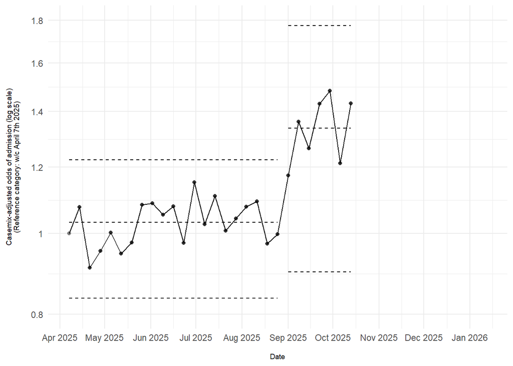

**Week 40**

Figure 21: An X chart for Salford Royal, showing the casemix-adjusted odds of admission over the 40 weeks following April 7th 2025.

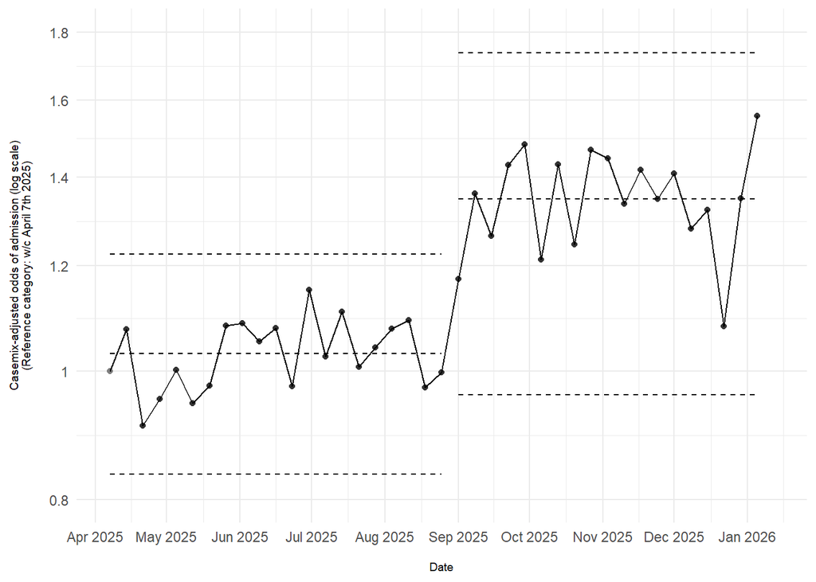

### Reproducibility

The computer code used in this analysis can be found a [GitHub repository](https://github.com/The-Strategy-Unit/tracking_adm_thresholds) (permissions currently required).

## 2.3 Discussion

Our analysis suggests that it may be feasible to design statistical models and associated tools to allow health systems to track casemix-adjusted admission thresholds in individual emergency departments. The models would need to be tuned to take account of the quality of each department’s Emergency Care Data Set submissions. The models we have proposed are moderately complex, and care would be required to ensure that users interpret the results appropriately. Users of these tools would likely require training and initial tailored support. Discussions with potential users would help guide decisions about the value and nature of any tool development and deployment.

## 2.4 Conclusion

In the second part of this report, we have outlined methods and visualisations that would allow local areas to monitor whether casemix-adjusted admission thresholds at their EDs are changing over time.

We suggest that many of the tables and charts presented here might be incorporated in a simple software application (app). Using this app, a user could choose any one of 180 EDs, view the current admission threshold at an ED, and examine how the threshold has changed over time.